# Untitled

James Wolpe

3/8/2022

All work presented is my own. I have not communicated with or worked with anyone else on this exam. James Wolpe

The maps package provides great maps

```r
#install.packages("maps")
library(maps)
```

However I want to make a map of a less common area so I will be using something called a shapefile. A few links in the course notes are useful for finding pre-made shapefiles, I selected one on New Hampshire from the census website.

To use shapefiles we will have to use a package called “sf”, which stands for “simple features” (not shapefiles).

```r
##install.packages("sf")
library(sf)
library(tidyverse)
```

We will now read in the shapefile and use the st_transform command to make the data workable.

```r
shp <- read_sf("cb_2018_33_bg_500k/cb_2018_33_bg_500k.shp") %>%
  st_transform(st_crs("+proj=longlat"))
```

Now we can draw a map, to do this we use the geom_sf function.

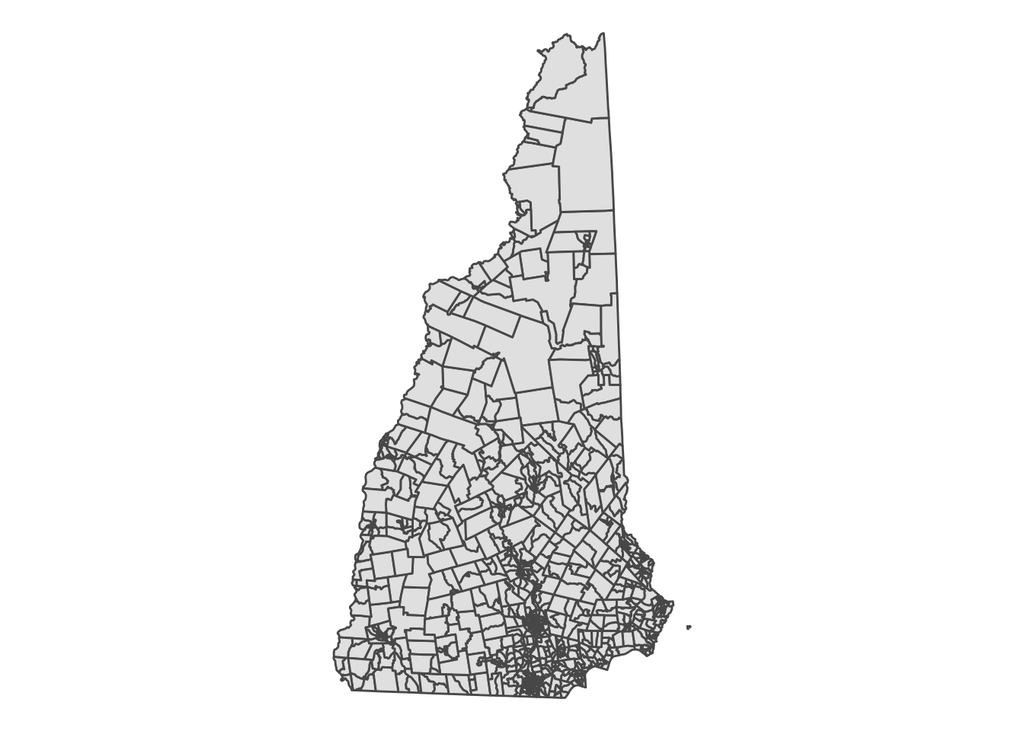

```r
library(tidyverse)
ggplot(data = shp) +
  geom_sf() +
  theme_void()
```

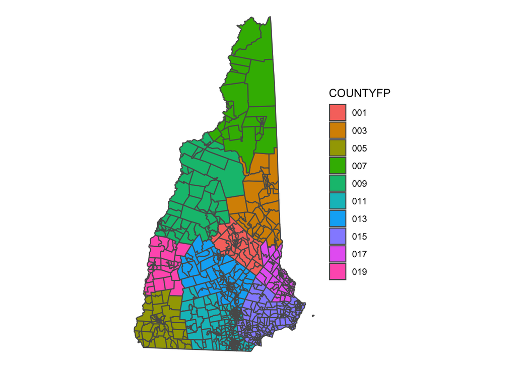

```r
ggplot(data = shp) +
  geom_sf(aes(fill = COUNTYFP)) +
  theme_void()
```

Success! This covers the basics of how to create a shapefile map. Of all the visualizations mapping is perhaps the most beautiful.